# Solving R_0

## Overview

The basic skeleton of all parameter estimation within these Ecological/SIR-ish/math models is that we have some set of parameters $\mathbb{\theta}$ that are unknown. But, we assume that we know the underlying model that is generating these observations over time (*i.e.* this is a time series problem). Given that this a time-series problem and our observations are generated by some underlying process, this problem can be characterized with the **hidden Markov model** framework.

#### Digression

If the models are simple enough, they have analytical solutions that can be determined by solving the ordinary differential equations (ODEs). We typically call these deterministic models. You can solve these models with a “simulation” or “optimization” based approach, but it’s not necessary. Most models aren’t simple…

### Approach

The basic steps for solving these models then is to simulate data under our set of parameters $\mathbb{\theta}$ and see how closely it matches truth.

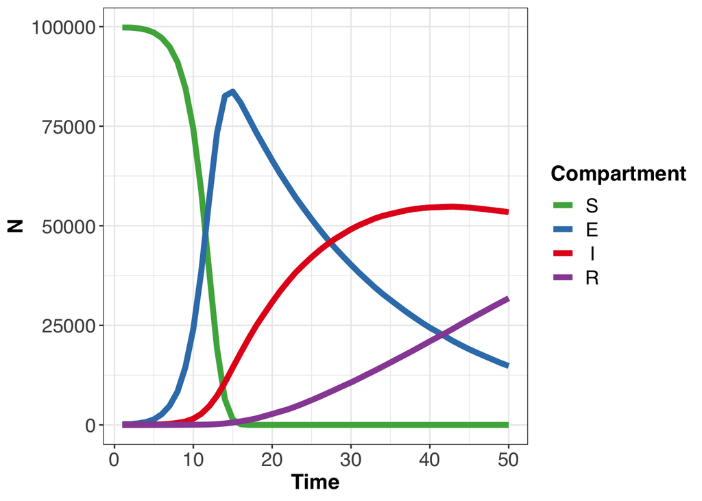

We don’t see full curve – only see infxns.

### Using `drjacoby` for MCMC inference of parameters

I now have a model that can generate data under a give set of parameters. Here, we are going to assume that we know the number of susceptible individuals and that this is a new, immunizing infeection. We will assume that we can only detect infectoins and that rates are poisson distributed. We want to estimate the $\beta$ parameter – which is the constant part of the force of infection (really estimating $\frac{\beta}{N}$ because in a frequency-dependent state) – as well as the $\mu_{EI}$ and $\mu_{IR}$ parameters, which represent decay into the infected from exposed and infected to recovered compartments.

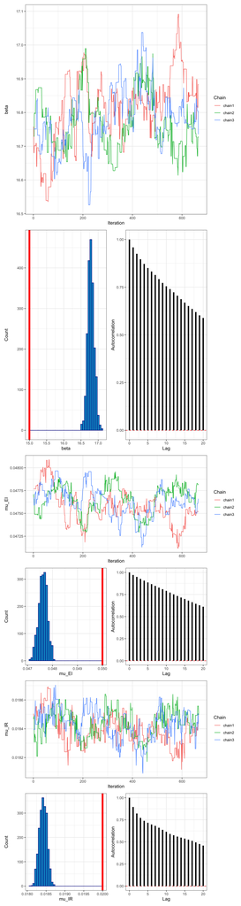